# DATA 558 - Data Competition Report

Will Wright

## Forward

As my first exposure to Python (coming from the world of R), I was sometimes unable to get a functioning result for parts of these competitions in the time alotted. I have, however, put together the results I obtained and point out where there were issues. Additionally, because most of this code was run in other notebooks, there are cases where screenshots were copied and pasted from them instead of re-computing.

## Introduction

```python
## Load Packages
# Math and Data Manipulation
import numpy as np
import pandas as pd
from random import sample
from random import choice
import scipy.linalg
import copy

# Plotting and Visuals
import matplotlib.pyplot as plt
import seaborn as sn
from IPython.display import Image
from IPython.core.display import HTML

# Machine Learning and Proprocessing
from sklearn.linear_model import LogisticRegression
from sklearn.linear_model import LogisticRegressionCV
import sklearn.linear_model
from sklearn.decomposition import PCA
from sklearn.metrics import confusion_matrix
from sklearn.metrics import precision_recall_fscore_support
from sklearn.model_selection import train_test_split
from sklearn import preprocessing
from sklearn.svm import LinearSVC
from sklearn.multiclass import OneVsOneClassifier
from sklearn.multiclass import OneVsRestClassifier

# Other
from tqdm import tqdm
import warnings
warnings.filterwarnings("ignore") # suppress conversion warnings
```

# Data Competition 1

The final model results are compared to a cohort of 44 students.

We'll start by loading the data after having extracted the image features:

```python
# Load data (if on Windows)
# x_train = np.load('C:/Users/Will/Documents/data_competition1_files/train_features.npy')
# y_train = np.load('C:/Users/Will/Documents/data_competition1_files/train_labels.npy')
# x_val = np.load('C:/Users/Will/Documents/data_competition1_files/val_features.npy')
# y_val = np.load('C:/Users/Will/Documents/data_competition1_files/val_labels.npy')

# Load data (if on Mac)
x_train_raw = np.load('/Users/willwright/Downloads/data_competition1_files/train_features.npy')
y_train = np.load('/Users/willwright/Downloads/data_competition1_files/train_labels.npy')
x_val_raw = np.load('/Users/willwright/Downloads/data_competition1_files/val_features.npy')
y_val = np.load('/Users/willwright/Downloads/data_competition1_files/val_labels.npy')
x_test_raw = np.load('/Users/willwright/Downloads/data_competition1_files/test_features.npy')
```

### Part 1 from Homework 3, Exercise 4

**Instructions**  
Pick two classes of your choice from the dataset. Train an $\ell_2^2$*-regularized logistic regression* classifier on the training set using your own fast gradient algorithm with $\lambda$ = 1. Be sure to use the features you generated above rather than the raw image features. Plot, with different colors, the *misclassification error* on the training set and on the validation set vs iterations.

**Comment** I wasn't able to get this working for the assignment, but I've used code from later assignments to try and retroactively attempt. I'm not proud of the results since it didn't come out as expected and I wasn't able to find the bug causing it. I'm sure with more time, I'd find the (likely) one line giving me issues.

```python
# Subset of data (selecting group 5 and 9)
class1 = 5
class2 = 9
```

```python
train_ids = np.array([np.where(y_train==class1),np.where(y_train==class2)]).reshape(-1)
x_train = x_train_raw[train_ids]
y_train = y_train_raw[train_ids]
val_ids = np.array([np.where(y_val==class1),np.where(y_val==class2)]).reshape(-1)
x_val = x_val_raw[val_ids]
y_val = y_val[val_ids]
```

```python
# Standardize data and update labels to +/- 1
x_train = preprocessing.scale(x_train).T
x_val = preprocessing.scale(x_val).T
y_train = y_train.T
y_train[y_train==class1] = 1
y_train[y_train==class2] = -1
y_val = y_val.T
y_val[y_val==class1] = 1
y_val[y_val==class2] = -1
```

Below are functions to compute the gradient, objective, initial eta, and backtracking eta. These subroutines are then fed into the fast gradient algorithm to train the logistic regression classifier.

```python
# Logistic Gradient
def computegrad(X, y, beta, lam = 0.05):
    'Output grad(F) given X, y, beta, and lambda'
    ## calc the nxn p-matrix
    # start with the diagonal of non-zeros
    n, d = X.shape
    P_diag = [0 for x in range(n)] # P is nxn
    for i in range(0,n):
        yXTbeta = y[i]*(X[i,:].T).dot(beta) # 1x1 * dx1 * 1xd = 1x1
        P_diag[i] = 1-(np.exp(yXTbeta))/(1+np.exp(yXTbeta))
    P = np.diagflat(P_diag) # nxn
    emp_risk = (-1/n)*(X.T.dot(P).dot(y.reshape(n,1))) # (dxn * nxn) = dxn; dxn * nx1 = dx1
    penalty = 2*lam*beta.reshape(d,1) # dx1
    grad_F = emp_risk + penalty #dx1 + dx1 = dx1
    return grad_F
```

```python
# Logistic Objective Value
def computeobj(X, y, beta, lam = 0.05):
    'Output F (objective is to minimize) for any given X, y, beta, lam'
    n = X.shape[0]
    sum_terms = [0 for i in range(n)] # initialize list
    for i in range(0, n):
        sum_terms[i] = np.log(1+np.exp(-y[i]*X[i,:].T.dot(beta)))
    avg_summation = sum(sum_terms)/n
    regularization = lam*np.sum(beta**2)
    F = avg_summation + regularization
    return F
```

```python
def backtracking(X, y, beta, eta, alpha = 0.5, gamma = 0.8):
    'Output new eta for a given X, y, beta, eta, alpha, and gamma'
    grad = computegrad(X,y,beta)
    complete = False
    while complete == False:
        if computeobj(X, y, beta - eta*grad) < computeobj(X, y, beta) - alpha*eta*np.linalg.norm(grad)**2:
            complete = True
        else:
            eta = eta * gamma
    return eta
```

```python
def compute_eta(X, lam = 0.05):
    'returns initial step-size based on equation provided in lecture notes'
    eigenValues, eigenVectors = np.linalg.eig((1/len(X)) * X.T.dot(X))
    L = max(eigenValues) + lam
    return 1/L
```

```python
def fastgradalgo(X, y, eta, target = 10e-4, lam = 0.05):
    '''initialize lists of betas, Fs, and grad(F)s;
    identical to standard gradient descent except theta is added and used in the computegrad subroutine'''
    beta = np.zeros((X.shape[1],1))
    theta = np.zeros((X.shape[1],1))
    betas = [beta] #start with the first beta included
    Fs = [computeobj(X,y,beta,lam)] # start with the first F included
    grad = computegrad(X,y,theta,lam)
    t=0
    while (np.linalg.norm(grad) > target):
        eta = backtracking(X, y, beta, eta)
        beta_prior = copy.copy(beta)
        beta = theta - eta * computegrad(X, y, theta, lam)
        theta = beta + (t/(t+3))*(beta - beta_prior)
        betas.append(beta)
        F = computeobj(X, y, beta, lam)
        Fs.append(F)
        grad = computegrad(X, y, theta, lam)
        t += 1
    return np.array(betas) #, np.array(Fs)
```

I had issues with my objective function and, for the purposes of testing the other functions, used the objective function provided in class so I could at least see if what I had worked:

```python
# Linear objective value (from class notes)
def obj(X, Y, beta, lamb):
    n = X.shape[1]
    return 1/n*np.sum(np.log(1+np.exp(np.multiply(-Y.T,X.T.dot(beta))))) + lamb*np.linalg.norm(beta)**2
```

```python
# Objective value by iteration plotter (from class notes)
def obj_plot(X1, Y1, X2, Y2, vals, lam, dim):
    n = vals.shape[0] # number of iterations
    obj1 = np.zeros(n)
    obj2 = np.zeros(n)
    for i in range(n):
        obj1[i] = obj(X1, Y1, vals[i],lam)
        obj2[i] = obj(X2, Y2, vals[i],lam)
    plt.figure()
    plt.plot(obj1, label='Training Set')
    plt.plot(obj2, label='Validation Set')
    plt.xlabel('Iteration')
    plt.ylabel('Objective Value')
    plt.title('Objective Value over Iterations\nDimension = %d' %dim, fontsize=13)
    plt.legend()
    plt.show()

    return
```

```python
vals_fg = fastgradalgo(x_train.T, y_train, compute_eta(x_train), lam=1)
```

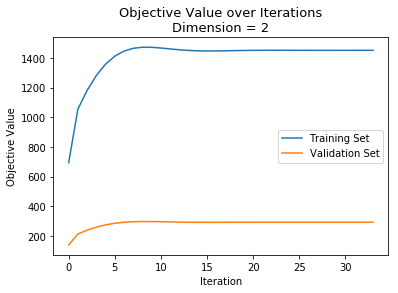

```python
# Plot objective values over iterations
obj_plot(x_train, y_train, x_val, y_val, vals_fg, 1, 2)
```

These should be down and to the right, but I wasn't able to get this working before we were onto the next assignment.

**Instructions**  
Find the value of the regularization parameter $\lambda$ using cross-validation; you may use scikit-learn’s built-in functions for this purpose. Train an $\ell_2^2$*-regularized logistic regression* classifier on the training set using your own fast gradient algorithm with that value of $\lambda$ found by cross-validation. Plot, with different colors, the misclassification error on the training set and on the validation set vs iterations.

```python
# Find optimal lambda by 5-fold cross-validation
n = x_train.shape[1]
clf = LogisticRegressionCV(cv=5, penalty='l2', fit_intercept=False, tol=10e-8, max_iter=1000)
fit = clf.fit(x_train.T, y_train)
lamb_opt = 1/(2*n*clf.C_[0])
print("The optimal value of lambda is", lamb_opt)
```

```
The optimal value of lambda is 0.08340502686000296
```

```python
vals_fg = fastgradalgo(x_train.T, y_train, compute_eta(x_train), lam=lamb_opt)
```

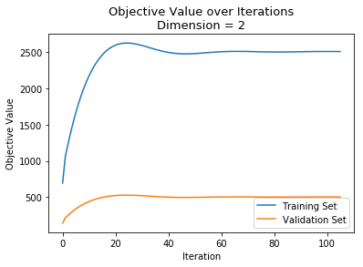

```python
# Plot objective values over iterations
obj_plot(x_train, y_train, x_val, y_val, vals_fg, 1, 2)
```

Again, this should be down and to the right, but I'm not sure where the issue is.

### Part 2 from Homework 4, Exercise 3

**Exercise Overview**  
In this exercise, PCA is conducted prior to training a logistic regression.

**Instructions**  
Pick two classes of your choice from the dataset

```python
# Subset of data (selecting group 5 and 9)
class1 = 5
class2 = 9
```

**Instructions**  
Run PCA on this subset of the data using Scikit-Learn and project the data down to two dimensions

```python
# PCA
pca = PCA(svd_solver='full')
pca = pca.fit(x_train.T)
print("The first principle component:\n", pca.components_[0])
print("\nThe second principle component:\n", pca.components_[1])

# Project subset data down to two dimensions
x_train_2 = np.array([pca.components_[0],pca.components_[1]]).dot(x_train)
x_val_2 = np.array([pca.components_[0],pca.components_[1]]).dot(x_val)
```

```
The first principle component:
 [ 0.00327121  0.03275855  0.01514789 ...  0.04599855 -0.0073089
 -0.02589495]

The second principle component:
 [-7.8337183e-03  1.8121632e-03  5.3832606e-05 ...  1.8176176e-02
  2.1943206e-02  1.6594676e-02]
```

**Instructions**  
You will be training an $l_2$-regularized logistic regression classifier. Find the value of the regularization paramater $\lambda$ using Scikit-Learn with 5-fold cross-validation.

```python
# Find optimal lambda by 5-fold cross-validation
n = x_train_2.shape[1]
clf = LogisticRegressionCV(cv=5, penalty='l2', fit_intercept=False, tol=10e-8, max_iter=1000)
fit = clf.fit(x_train_2.T, y_train)
lamb_opt = 1/(2*n*clf.C_[0])
print("The optimal value of lambda is", lamb_opt)
```

```
The optimal value of lambda is 0.010772173450159423
```

```python
# Train on the training set
vals_fg = fastgradalgo(x_train_2.T, y_train, compute_eta(x_train_2), lam=lamb_opt)
```

Objective value results from logistic classifier:

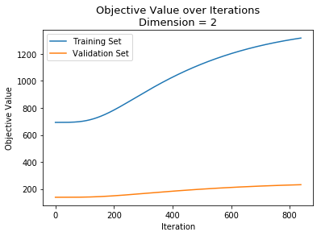

```python
# Plot objective values over iterations
obj_plot(x_train_2, y_train, x_val_2, y_val, vals_fg, lamb_opt, 2)
```

Hmm, it must be an issue with the plotter since the accuracy results within the Midterm portion align with the rest of the class.

**Instructions**  
Repeat steps b-d, trying all power of two up to the number of features in the dataset.

```python
# TODO; had issues during assignment
```

**Instructions**  
Plot, with different colors, the misclassification error on the training set and on the test set vs. the dimension of the projection. Note that to obtain the performance on the test set you will need to submit to Kaggle, and you can only submit three times per day. If you only have enough tiem for three submissions, submit your predictions for dimensions 2, 16, 128.

```python
# TODO; had issues during assignment
```

### Part 3 from Midterm, Exercise 2

**Exercise Overview**  
This exercise involved exploring a rho-logistic regression classifier. It's very similar to logistic regression, but a rho-term was added to the loss function.

**Comments**  
This exercise is the one I'm most proud of—I was able to get *most* of the expected results, though in some cases the performance of my algorithms was better than it should have been and this is suspicious.

Below, subroutines are created (or redefined) for the rho-logistic classifier to call:

```python
# rho logistic gradient
def computegrad(beta, lamb, rho, x, y):
    yx = y[:, np.newaxis]*x
    denom = 1+np.exp(-rho*yx.dot(beta))
    grad = -1/len(y)*np.sum(yx*np.exp(-rho*yx.dot(beta[:, np.newaxis]))/
        denom[:, np.newaxis], axis=0) + 2*lamb*beta
    return grad

# rho logistic objective
def computeobj(beta, lamb, rho, x, y):
    return 1/len(y) * np.sum(1/rho*np.log(1 + np.exp(-rho*y*x.dot(beta)))) + lamb*np.linalg.norm(beta)**2

# backtracking with rho logistic
def backtracking(beta, lamb, rho, x, y, eta, alpha=0.5, gamma=0.8):
    grad_beta = computegrad(beta, lamb, rho, x, y)
    norm_grad_beta = np.linalg.norm(grad_beta)
    found_eta = False
    iter = 0
    while found_eta == False:
        if computeobj(beta - eta * grad_beta, lamb, rho, x, y) < \
            computeobj(beta, lamb, rho, x, y)- alpha * eta * norm_grad_beta ** 2:
                found_eta = True
        else:
            eta *= gamma
            iter += 1
    return eta
```

```python
def computeEtaInit(x, y, lamb):
    eta_init = 1/(scipy.linalg.eigh(1/len(y)*x.T.dot(x),
                                eigvals=(d-1, d-1),
                                eigvals_only=True)[0]+lamb)
    return eta_init
```

These functions are fed into the rho logistic classifier:

```python
def myrhologistic(x, y, beta_init, theta_init, lamb, rho, eta_init, eps):
    beta = beta_init
    theta = theta_init
    eta = eta_init
    grad_theta = computegrad(theta, lamb, rho, x, y)
    grad_beta = computegrad(beta, lamb, rho, x, y)
    beta_vals = beta
    theta_vals = theta
    iter = 0
    while np.linalg.norm(grad_beta) > eps:
        eta = backtracking(theta, lamb, rho, x, y, eta)
        beta_new = theta - eta*grad_theta
        theta = beta_new + iter/(iter+3)*(beta_new-beta)
        beta_vals = np.vstack((beta_vals, beta))
        theta_vals = np.vstack((theta_vals, theta))
        grad_theta = computegrad(theta, lamb, rho, x, y)
        grad_beta = computegrad(beta, lamb, rho, x, y)
        beta = beta_new
        iter += 1
    return beta_vals
```

Below are functions to calculate the error and determine the optimal lambda via leave-one-out (loocv) and hold-out (hocv) cross-validation:

```python
def compute_error(x, y, beta):
    y_pred = 1/(1+np.exp(-x.dot(beta))) > 0.5
    y_pred = y_pred*2 - 1 # Convert to +/- 1
    return np.mean(y_pred != y)
```

```python
def loocv(x, y, lamb, rho, eps):
    n, d = x.shape
    beta_init = np.zeros(d)
    theta_init = np.zeros(d)
    errors = []
    for i in tqdm(range(n)):
        x_loo = np.vstack((x[0:i,:],x[(i+1):,:]))
        y_loo = np.concatenate([y[0:i],y[(i+1):]])
        eta_init = computeEtaInit(x_loo, y_loo, lamb)
        loo_betas = myrhologistic(x_loo, y_loo, beta_init, theta_init, lamb, rho, eta_init, eps)
        loo_beta_opt = loo_betas[-1,:]
        errors.append(compute_error(x_train, y_train, loo_beta_opt))
    return np.sum(errors)/n
```

```python
def hocv(x, y, lamb, eps, rho, test_size = 0.2):
    x_train, x_test, y_train, y_test = train_test_split(x, y, test_size = test_size)
    d = x_train.shape[1]
    beta_init = np.zeros(d)
    theta_init = np.zeros(d)
    eta_init = computeEtaInit(x_train, y_train, lamb)
    ho_betas = myrhologistic(x_train, y_train, beta_init, theta_init, lamb, rho, eta_init, eps)
    ho_beta_opt = ho_betas[-1,:]
    error = compute_error(x_test, y_test, ho_beta_opt)
    return error
```

```python
lamb_vals = []
for i in range(-3,3):
    lamb_vals.append(10**i) # testing very small to very large
```

In hindsight, I think I could have achieved greater performance if, after running initially, I tightened up the possible lambda values to have smaller increments around the optimal value.

```python
def compute_lamb_opt(x, y, lamb_vals, eps, rho, method, test_size = 0.2):
    if method=='loocv':
        errors = []
        for lamb in lamb_vals:
            error = loocv(x, y, lamb, rho, eps)
            errors.append(error)
        minpos = errors.index(min(errors))
        lamb_opt = lamb_vals[minpos]
        return lamb_opt
    if method=='hocv':
        errors = []
        for lamb in lamb_vals:
            error = hocv(x, y, lamb, eps, rho, test_size)
            errors.append(error)
        minpos = errors.index(min(errors))
        lamb_opt = lamb_vals[minpos]
        return lamb_opt
    else:
        print('Unknown method')
```

**Instructions**  
Pick two classes of your choice from the dataset. Train a classifier using $\ell_2^2$-regularized binary logistic regression with $\rho$-logistic loss on the training set using your own accelerated gradient algorithm with $\rho = 2$, $\epsilon = 10^{−3}$, and $\lambda = 1$. Be sure to use the features you previously generated with the provided script rather than the raw image features. Plot, with different colors, the misclassification error on the training set and on the validation set vs iterations.

```python
# Reload the data

# Load data (if on Windows)
# x_train = np.load('C:/Users/Will/Documents/data_competition1_files/train_features.npy')
# y_train = np.load('C:/Users/Will/Documents/data_competition1_files/train_labels.npy')
# x_val = np.load('C:/Users/Will/Documents/data_competition1_files/val_features.npy')
# y_val = np.load('C:/Users/Will/Documents/data_competition1_files/val_labels.npy')

# Load data (if on Mac)
x_train_raw = np.load('/Users/willwright/Downloads/data_competition1_files/train_features.npy')
y_train = np.load('/Users/willwright/Downloads/data_competition1_files/train_labels.npy')
x_val_raw = np.load('/Users/willwright/Downloads/data_competition1_files/val_features.npy')
y_val = np.load('/Users/willwright/Downloads/data_competition1_files/val_labels.npy')
x_test_raw = np.load('/Users/willwright/Downloads/data_competition1_files/test_features.npy')
```

```python
# Subset of data (selecting group 5 and 9)
class1 = 5
class2 = 9
train_ids = np.array([np.where(y_train==class1),np.where(y_train==class2)]).reshape(-1)
x_train = x_train_raw.copy()[train_ids]
y_train = y_train.copy()[train_ids]
val_ids = np.array([np.where(y_val==class1),np.where(y_val==class2)]).reshape(-1)
x_val = x_val_raw.copy()[val_ids]
y_val = y_val.copy()[val_ids]
```

```python
# change indicators from the original classes to +1/-1
y_train[y_train==class1] = 1
y_train[y_train==class2] = -1
y_val[y_val==class1] = 1
y_val[y_val==class2] = -1
```

```python
# Standardize
x_standardizer = preprocessing.StandardScaler()
x_train = x_standardizer.fit_transform(x_train)
x_val = x_standardizer.fit_transform(x_val)
```

```python
# Initialize parameters
n, d = x_train.shape
rho = 2
eps = 10**-3
lamb = 1
beta_init = np.zeros(d)
theta_init = np.zeros(d)
eta_init = computeEtaInit(x_train, y_train, lamb)
```

```python
# Train Model
kaggle_betas = myrhologistic(x_train, y_train, beta_init, theta_init, lamb, rho, eta_init, eps)
```

```python
def plot_misclassification_errors(x_train, y_train, x_val, y_val, betas):
    iterations = betas.shape[0]
    train_errors = []
    val_errors = []
    for i in range(iterations):
        train_error = compute_error(x_train, y_train, betas[i,:])
        train_errors.append(train_error)
        val_error = compute_error(x_val, y_val, betas[i,:])
        val_errors.append(val_error)
    plt.plot(train_errors, color = "blue")
    plt.plot(val_errors, color = "red")
    plt.ylabel("Misclassification Rate")
    plt.xlabel("Iterations")
    plt.title("Misclassification Rates by Iteration")
    plt.legend(["Training Data", "Validation Data"])
    plt.show()
```

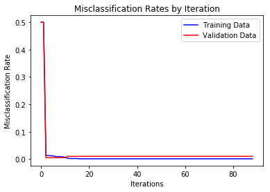

```python
# Plot misclassification error on the training set by iteration
plot_misclassification_errors(x_train, y_train, x_val, y_val, kaggle_betas)
```

```python
print('Training Misclassificaiton Rate: ',compute_error(x_train, y_train, kaggle_betas[-1,:]))
print('Validation Misclassificaiton Rate: ',compute_error(x_val, y_val, kaggle_betas[-1,:]))
```

```
Training Misclassificaiton Rate:  0.001
Validation Misclassificaiton Rate:  0.01
```

**Comments** These results are suspicious because they're so good. I'd expect the transition from 50% misclassification to a small amount to be over several iterations, not immediate.

**Instructions**  
Find the value of the regularization parameter $\lambda$ using using leave-one-out cross-validation. Find the value of the regularization parameter $\lambda$ using using hold-out cross-validation. Train a classifier using $\ell_2^2$-regularized binary logistic regression with $\rho$-logistic loss on the training set using your own accelerated gradient algorithm with that value of $\lambda$ found by hold-out cross-validation. Plot, with different colors, the misclassification error on the training set and on the validation set vs. iterations.

#### LOOCV

```python
loocv_lamb_opt = compute_lamb_opt(x_train, y_train, lamb_vals, eps, rho, method = 'loocv')
loocv_error = loocv(x_train, y_train, loocv_lamb_opt, rho, eps)
print('Leave-one-out optimal lambda is: ',loocv_lamb_opt)
print('Leave-one-out misclassification rate: ',loocv_error)
```

This would multiple days to run so I took a sub-sample:

```python
sample_train_index = sample(list(range(len(x_train))),50)
x_train_sample = x_train.copy()[sample_train_index]
y_train_sample = y_train.copy()[sample_train_index]
sample_val_index = sample(list(range(len(x_val))),50)
x_val_sample = x_val.copy()[sample_val_index]
y_val_sample = y_val.copy()[sample_val_index]
```

```python
loocv_lamb_opt = compute_lamb_opt(x_train_sample, y_train_sample, lamb_vals, eps, rho, method = 'loocv')
loocv_error = loocv(x_train_sample, y_train_sample, loocv_lamb_opt, rho, eps)
```

```python
print('Leave-one-out optimal lambda is: ',loocv_lamb_opt)
print('Leave-one-out misclassification rate: ',loocv_error)
```

This was run for the assignment, but since it takes forever to run, the resulting output was:  
Leave-one-out optimal lambda is: 100  
Leave-one-out misclassification rate: 0.01582

```python
# Train model with ideal lambda, as computed by LOOCV
loocv_lamb_opt_betas = myrhologistic(x_train_sample, y_train_sample,
                                     beta_init, theta_init, loocv_lamb_opt, rho, eta_init, eps)
```

```python
plot_misclassification_errors(x_train_sample, y_train_sample, x_val_sample, y_val_sample, loocv_lamb_opt_betas)
```

(I took a screenshot of the results instead of re-running):

```python
PATH = "/Users/willWright/UW/DATA558/WEEK09/"
```

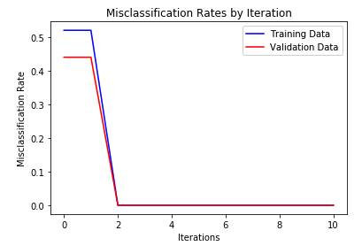

```python
Image(filename = PATH + "screenshot01.png", width=400)
```

This could be due to the sub-sampling, but it's certainly suspicious. Why would there be no change until the 3rd iteration when it snaps perfectly to 0%??

```python
print('Training Misclassificaiton Rate: ',compute_error(x_train_sample, y_train_sample, loocv_lamb_opt_betas[-1,:]))
print('Validation Misclassificaiton Rate: ',compute_error(x_val_sample, y_val_sample, loocv_lamb_opt_betas[-1,:]))
```

This, too, was run for the assignment and I've copied the output below:  
Training Misclassificaiton Rate: 0.0  
Validation Misclassificaiton Rate: 0.0

#### HOCV

```python
hocv_lamb_opt = compute_lamb_opt(x_train, y_train, lamb_vals, eps, rho, method = 'hocv')
hocv_error = hocv(x_train, y_train, hocv_lamb_opt, eps, rho, test_size = 0.2)
print('80/20 Hold-out optimal lambda is: ',hocv_lamb_opt)
print('80/20 Hold-out misclassification rate: ',hocv_error)
```

80/20 Hold-out optimal lambda is: 0.001  
80/20 Hold-out misclassification rate: 0.0

Not sure what to make of a perfect accuracy other than: something is probably wrong...

```python
# Train model with ideal lambda, as computed by HOCV
hocv_lamb_opt_betas = myrhologistic(x_train, y_train, beta_init, theta_init, hocv_lamb_opt, rho, eta_init, eps)
```

```python
plot_misclassification_errors(x_train, y_train, x_val, y_val, hocv_lamb_opt_betas)
```

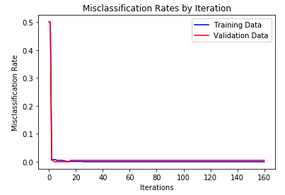

```python
Image(filename = PATH + "screenshot02.png", width=400)
```

```python
print('Training Misclassificaiton Rate: ',compute_error(x_train, y_train, hocv_lamb_opt_betas[-1,:]))
print('Validation Misclassificaiton Rate: ',compute_error(x_val, y_val, hocv_lamb_opt_betas[-1,:]))
```

This is an *obscenely* good misclassification rate. I'm unsure why I'm getting these results after having attempted to resolve.

**Instructions**  
Consider all pairs of classes from the dataset. For each pair of classes, train a classifier using a $\ell_2^2$-regularized binary logistic regression with $\rho$-logistic loss on the training set comprising only the data-points for that pair of classes using your own fast gradient algorithm. For each pair of classes, find the value of the regularization parameter $\lambda$ using hold-out cross-validation on the training set comprising only the data-points for that pair of classes.

```python
class_possibilities = np.unique(y_train)
```

```python
# create array of all possible pairs
all_pairs = np.empty((0,2),int)
for i in class_possibilities:
    for j in class_possibilities:
        all_pairs = np.append(all_pairs,
                              np.array([class_possibilities[i],class_possibilities[j]]).reshape(1,2),
                              axis = 0)
```

```python
keep_index = []
for i in range(len(all_pairs)):
    # remove pairs with same class
    if all_pairs[i,0] != all_pairs[i,1]:
        # remove pairs already in the array higher up, but in different order
        if any(([all_pairs[i,1],all_pairs[i,0]] == x).all() for x in list(all_pairs[0:i-1]))==False:
            keep_index.append(i)
```

```python
all_pairs = all_pairs[keep_index]
```

```python
lambdas_opt = []
models = []
for i in tqdm(range(len(all_pairs))):
    # Subset to pair
    class1, class2 = all_pairs[i]
    train_ids = np.array([np.where(y_train_raw==class1),np.where(y_train_raw==class2)]).reshape(-1)
    x_train = x_train_raw[train_ids]
    y_train = y_train_raw[train_ids]
    val_ids = np.array([np.where(y_val_raw==class1),np.where(y_val_raw==class2)]).reshape(-1)
    x_val = x_val_raw[val_ids]
    y_val = y_val_raw[val_ids]
    # Replace class indicators with +/-1; make sure to set -1 to avoid converting all values to 1 (if the class2 is 1)
    y_train[y_train==class2] = -1
    y_train[y_train==class1] = 1
    y_val[y_val==class2] = -1
    y_val[y_val==class1] = 1
    # Standardize
    x_standardizer = preprocessing.StandardScaler()
    x_train = x_standardizer.fit_transform(x_train)
    x_val = x_standardizer.fit_transform(x_val)
    # Calculate optimal lambda
    hocv_lamb_opt = compute_lamb_opt(x_train, y_train, lamb_vals, eps, rho, method = 'hocv')
    lambdas_opt.append(hocv_lamb_opt)
    # train model with optimal lambda
    betas = myrhologistic(x_train,
                          y_train,
                          beta_init,
                          theta_init,
                          lambdas_opt[i],
                          rho,
                          computeEtaInit(x_train, y_train, lambdas_opt[i]),
                          eps)
    betas_opt = betas[-1]
    models.append(betas_opt)
```

```
0it [00:00, ?it/s]
```

**Instructions**  
Write a function that for any new data point predicts its label. To do this, you will perform the following: input the data point into each classifier (for each pair of classes) you trained above. Record the class predicted by each classifier. Then your prediction for this data point is the most frequently predicted class. If there is a tie, randomly choose between the tied classes. Report the misclassification error on the validation set and test set. Report the precision/recall on the validation set.

```python
def compute_prediction(x, y, beta):
    y_pred = 1/(1+np.exp(-x.dot(beta))) > 0.5
    y_pred = y_pred*2 - 1 # Convert to +/- 1
    return y_pred
```

```python
# Set train/validation/test to total dataset
x_train = x_train_raw.copy()
y_train = y_train.copy()
x_val = x_val_raw.copy()
y_val = y_val.copy()
x_test = x_test_raw.copy()

# Standardize
x_standardizer = preprocessing.StandardScaler()
x_train = x_standardizer.fit_transform(x_train)
x_val = x_standardizer.fit_transform(x_val)
x_test = x_standardizer.fit_transform(x_test)
```

#### Training set predictions and results

```python
train_predictions = np.zeros((len(y_train),len(models)))
```

```python
for i in range(len(y_train)):
    for j in range(len(models)):
        train_predictions[i,j] = compute_prediction(x_train[i], y_train[i], models[j])
```

```python
# convert from +/-1 to the original class
for i in range(train_predictions.shape[0]):
    for j in range(train_predictions.shape[1]):
        if train_predictions[i,j]==1:
            train_predictions[i,j]=all_pairs[j,0]
        else:
            train_predictions[i,j]=all_pairs[j,1]
```

```python
def countX(lst, x):
    return lst.count(x)
```

```python
# for each data point, pick either the most occurring prediction by all the classifiers or, if tie, random between
# the tied classes
train_prediction_results = []
for i in range(len(train_predictions)):
    freq = []
    for j in class_possibilities:
        freq.append(countX(list(train_predictions[i]),class_possibilities[j]))
    prediction = class_possibilities[choice([k for k,x in enumerate(freq) if x==max(freq)])]
    train_prediction_results.append(prediction)
```

```python
freq = []
for i in class_possibilities:
    freq.append(countX(train_prediction_results,class_possibilities[i]))
```

```python
# show results
pd.DataFrame({'Class': class_possibilities, 'Freq': freq})
```

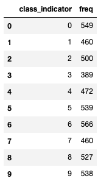

```python
Image(filename = PATH + "screenshot03.png", width=150)
```

```python
# misclassification on the test set
print('Training Misclassificaiton Rate: ',np.mean(train_prediction_results != y_train))
```

Training Misclassificaiton Rate: 0.0664

```python
train_conf_matrix = confusion_matrix(y_train, train_prediction_results)
```

```python
array = train_conf_matrix
df_cm = pd.DataFrame(array, index = class_possibilities,
                  columns = class_possibilities)
plt.figure(figsize = (10,7))
sn.set(font_scale=1.4)#for label size
sn.heatmap(df_cm, annot=True,annot_kws={"size": 16}, fmt = 'g')# font size
```

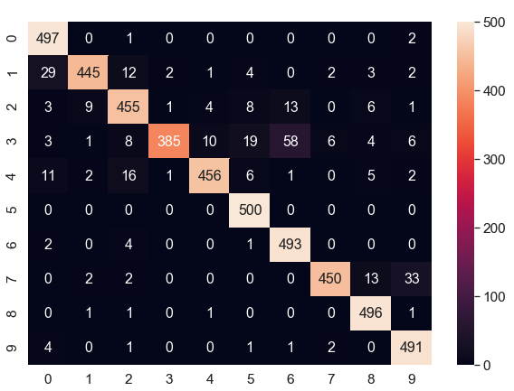

```python
Image(filename = PATH + "screenshot04.png", width=500)
```

```python
precision, recall, fscore, support = precision_recall_fscore_support(y_train, train_prediction_results)
```

```python
pd.DataFrame({'Class': class_possibilities,
             'Training Pecision': precision,
             'Training Recall': recall,})
```

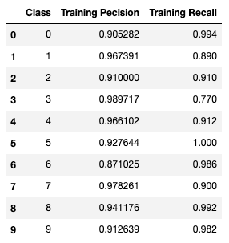

```python
Image(filename = PATH + "screenshot05.png", width=300)
```

#### Validation set predictions and results

```python
val_predictions = np.zeros((len(y_val),len(models)))
for i in range(len(y_val)):
    for j in range(len(models)):
        val_predictions[i,j] = compute_prediction(x_val[i], y_val[i], models[j])

# convert from +/-1 to the original class
for i in range(val_predictions.shape[0]):
    for j in range(val_predictions.shape[1]):
        if val_predictions[i,j]==1:
            val_predictions[i,j]=all_pairs[j,0]
        else:
            val_predictions[i,j]=all_pairs[j,1]

# for each data point, pick either the most occurring prediction by all the classifiers or, if tie, random between
# the tied classes
val_prediction_results = []
for i in range(len(val_predictions)):
    freq = []
    for j in class_possibilities:
        freq.append(countX(list(val_predictions[i]),class_possibilities[j]))
    prediction = class_possibilities[choice([k for k,x in enumerate(freq) if x==max(freq)])]
    val_prediction_results.append(prediction)

freq = []
for i in class_possibilities:
    freq.append(countX(val_prediction_results,class_possibilities[i]))

# show results
pd.DataFrame({'Class Indicator': class_possibilities, 'Freq': freq})
```

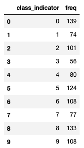

```python
Image(filename = PATH + "screenshot09.png", width=180)
```

```python
# misclassification on the test set
print('Validation Misclassificaiton Rate: ',np.mean(val_prediction_results != y_val))
```

Validation Misclassificaiton Rate: 0.256

```python
val_conf_matrix = confusion_matrix(y_val, val_prediction_results)
```

```python
array = val_conf_matrix
df_cm = pd.DataFrame(array, index = class_possibilities,
                  columns = class_possibilities)
plt.figure(figsize = (10,7))
sn.set(font_scale=1.4)#for label size
sn.heatmap(df_cm, annot=True,annot_kws={"size": 16}, fmt = 'g')# font size
```

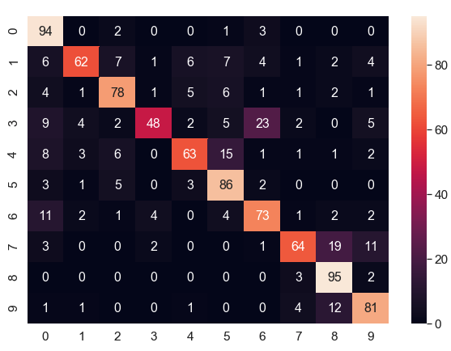

```python
Image(filename = PATH + "screenshot06.png", width=500)
```

```python
precision, recall, fscore, support = precision_recall_fscore_support(y_val, val_prediction_results)
```

```python
pd.DataFrame({'Class': class_possibilities,
             'Training Pecision': precision,
             'Training Recall': recall,})
```

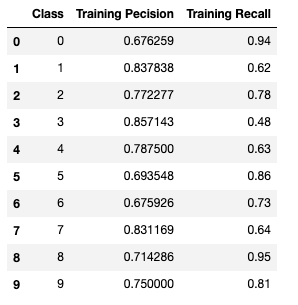

```python
Image(filename = PATH + "screenshot07.png", width=300)
```

#### Test set predictions

```python
test_predictions = np.zeros((len(y_val),len(models)))
for i in range(len(y_val)):
    for j in range(len(models)):
        test_predictions[i,j] = compute_prediction(x_test[i], y_val[i], models[j]) # y isn't used in the function

# convert from +/-1 to the original class
for i in range(test_predictions.shape[0]):
    for j in range(test_predictions.shape[1]):
        if test_predictions[i,j]==1:
            test_predictions[i,j]=all_pairs[j,0]
        else:
            test_predictions[i,j]=all_pairs[j,1]

# for each data point, pick either the most occurring prediction by all the classifiers or, if tie, random between
# the tied classes
test_prediction_results = []
for i in range(len(test_predictions)):
    freq = []
    for j in class_possibilities:
        freq.append(countX(list(test_predictions[i]),class_possibilities[j]))
    prediction = class_possibilities[choice([k for k,x in enumerate(freq) if x==max(freq)])]
    test_prediction_results.append(prediction)

freq = []
for i in class_possibilities:
    freq.append(countX(test_prediction_results,class_possibilities[i]))

# show results
pd.DataFrame({'Class Indicator': class_possibilities, 'Freq': freq})
```

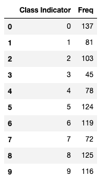

```python
Image(filename = PATH + "screenshot08.png", width=180)
```

Write to .csv for submission:

```python
kaggle_submission = pd.DataFrame({'Id':range(1000),'Category':test_prediction_results})
```

```python
kaggle_submission.to_csv('willWright_submission.csv', index = False)
```

Results from submission below:  
Kaggle's Score: 71.285% (highest score was 77.428%)  
Rank: 25/44

# Data Competition 2

### Part 1 from Homework 6, Exercise 4

Pick two classes of your choice from the dataset. Train an $\ell_2^2$-regularized logistic regression classifier on the training set using your own fast gradient algorithm with $\lambda = 1$. Plot, with different colors, the misclassification error on the training set and on the validation set vs iterations.

**Comment** I was unable to get a functioning SVM and, as such, could not complete this part.

```python
# TODO; ran into issues during homework
```

Find the value of the regularization parameter $\lambda$ using cross-validation; you may use scikit-learn’s built-in functions for this purpose. Train an $\ell_2^2$ -regularized logistic regression classifier on the training set using your own fast gradient algorithm with that value of $\lambda$ found by cross-validation. Plot, with different colors, the misclassification error on the training set and on the validation set vs iterations.

**Comment** I was unable to get a functioning SVM and, as such, could not complete this part.

```python
# TODO; ran into issues during homework
```

### Part 2 from Homework 7, Exercise 3

**Exercise Overview**  
In this exercise, you are going to train support vector machines (SVMs) using the data competition 2 project dataset (with 100 classes). You will consider here all classes in the dataset. You may work on this exercise on your own computer first. Note, however, that you need AWS to run the experiments for this entire exercise.

**Instructions**  
In a one-vs-one fashion, for each pair of classes, train a linear SVM classifier using scikitlearn’s function LinearSVC, with the default value for the regularization parameter. Compute the *multi-class* *misclassification error* obtained using these classifiers trained in a one-vs-one fashion.

```python
# Load data (Windows)
x_train_raw = np.load('C:/Users/Will/Documents/data_competition2_files/train_features.npy')
y_train = np.load('C:/Users/Will/Documents/data_competition2_files/train_labels.npy')
x_val_raw = np.load('C:/Users/Will/Documents/data_competition2_files/val_features.npy')
y_val = np.load('C:/Users/Will/Documents/data_competition2_files/val_labels.npy')
x_test_raw = np.load('C:/Users/Will/Documents/data_competition2_files/test_features.npy')

# # Load data (Mac)
# x_train_raw = np.load('/Users/willwright/Downloads/data558spring2019-competition2/train_features.npy')
# y_train = np.load('/Users/willwright/Downloads/data558spring2019-competition2/train_labels.npy')
# x_val_raw = np.load('/Users/willwright/Downloads/data558spring2019-competition2/val_features.npy')
# y_val = np.load('/Users/willwright/Downloads/data558spring2019-competition2/val_labels.npy')
# x_test_raw = np.load('/Users/willwright/Downloads/data558spring2019-competition2/test_features.npy')
```

```python
# Standardize x
x_standardizer = preprocessing.StandardScaler()
x_train = x_standardizer.fit_transform(x_train_raw)
x_val = x_standardizer.fit_transform(x_val_raw)
x_test = x_standardizer.fit_transform(x_test_raw)
```

```python
OneVsOne_pred = OneVsOneClassifier(
    LinearSVC(random_state=0, tol=1e-5, fit_intercept=False
             )).fit(x_train,y_train).predict(x_val)

np.mean(OneVsOne_pred==y_val)
```

Without re-running due to the computational expensiveness, the output was:  
0.5423

**Instructions**  
In a one-vs-rest fashion, for each class, train a linear SVM classifier using scikit-learn’s function LinearSVC, with the default value for $\lambda_c$. Compute the multi-class misclassification error obtained using these classifiers trained in a one-vs-rest fashion

```python
OneVsRest_pred = OneVsRestClassifier(
    LinearSVC(random_state=0, tol=1e-5, fit_intercept=False
             )).fit(x_train[:10000,:],y_train[:10000]).predict(x_val[:2000,:])

np.mean(OneVsRest_pred==y_val[:2000])
```

0.6505

**Comments** It took 1m41s to classify 10 categories with 10,000 samples and 51m17s to do 20 categories with 20,000 samples. Given what seems to be an exponential growth, I'll need AWS to do the full 50,000.

```python
OneVsOne_kaggle_pred = OneVsOneClassifier(
    LinearSVC(random_state=0, tol=1e-5, fit_intercept=False
             )).fit(x_train,y_train).predict(x_test)
```

```python
kaggle_submission = pd.DataFrame({'Id':range(10000),'Category':OneVsOne_kaggle_pred})
```

```python
kaggle_submission.to_csv('willWright_competition2_submission.csv', index = False)
```

Results from submsision below:  
Kaggle's Evaluated Accuracy: 55.5566%  
Rank: 12/44

**Instructions**  
Redo all questions above now using your own code for the linear SVMs from Exercise 1. Make to sure to run preliminary experiments to decide how to set the stopping criterion to a value that allows the experiments to complete in a reasonable amount of time.

**Comment** I was unable to get a functioning SVM and, as such, could not complete this part.

```python
# TODO; ran into issues during assignment
```

### Final Thoughts

Though I wasn't able to always get the expected results, I learned a lot about both Python and machine learning over the course of these competitions. I'm sure I'll return to this notebook (as well as all the labs and homeworks) as a resource going into the future.